# Lab10

Marlee Galloway

12/5/2020

# Examples

## Example data provided with the R package vcfR (Knaus and Grünwald 2017).

```r
library(vcfR)
data(vcfR_example)
vcf
```

```
## ***** Object of Class vcfR *****
## 18 samples
## 1 CHROMs
## 2,533 variants
## Object size: 3.2 Mb
## 8.497 percent missing data
## *****        *****         *****
```

# The meta region:

## Ex:

```r
strwrap(vcf@meta[1:7])
```

```
## [1] "##fileformat=VCFv4.1"
## [2] "##source=\"GATK haplotype Caller, phased with beagle4\""
## [3] "##FILTER=<ID=LowQual,Description=\"Low quality\">"
## [4] "##FORMAT=<ID=AD,Number=.,Type=Integer,Description=\"Allelic depths for"
## [5] "the ref and alt alleles in the order listed\">"
## [6] "##FORMAT=<ID=DP,Number=1,Type=Integer,Description=\"Approximate read"
## [7] "depth (reads with MQ=255 or with bad mates are filtered)\">"
## [8] "##FORMAT=<ID=GQ,Number=1,Type=Integer,Description=\"Genotype Quality\">"
## [9] "##FORMAT=<ID=GT,Number=1,Type=String,Description=\"Genotype\">"
```

# Function to compress data from long lines:

```r
queryMETA(vcf)
```

```
##  [1] "FILTER=ID=LowQual"
##  [2] "FORMAT=ID=AD"
##  [3] "FORMAT=ID=DP"
##  [4] "FORMAT=ID=GQ"
##  [5] "FORMAT=ID=GT"
##  [6] "FORMAT=ID=PL"
##  [7] "GATKCommandLine=ID=HaplotypeCaller"
##  [8] "INFO=ID=AC"
##  [9] "INFO=ID=AF"
## [10] "INFO=ID=AN"
## [11] "INFO=ID=BaseQRankSum"
## [12] "INFO=ID=ClippingRankSum"
## [13] "INFO=ID=DP"
## [14] "INFO=ID=DS"
## [15] "INFO=ID=FS"
## [16] "INFO=ID=HaplotypeScore"
## [17] "INFO=ID=InbreedingCoeff"
## [18] "INFO=ID=MLEAC"
## [19] "INFO=ID=MLEAF"
## [20] "INFO=ID=MQ"
## [21] "INFO=ID=MQ0"
## [22] "INFO=ID=MQRankSum"
## [23] "INFO=ID=QD"
## [24] "INFO=ID=ReadPosRankSum"
## [25] "INFO=ID=SOR"
## [26] "1 contig=<IDs omitted from queryMETA"
```

# Element parameters ruturn only information about that element:

```r
queryMETA(vcf, element = 'DP')
```

```
## [[1]]
## [1] "FORMAT=ID=DP"
## [2] "Number=1"
## [3] "Type=Integer"
## [4] "Description=Approximate read depth (reads with MQ=255 or with bad mates are filtered)"
##
## [[2]]
## [1] "INFO=ID=DP"
## [2] "Number=1"
## [3] "Type=Integer"
## [4] "Description=Approximate read depth; some reads may have been filtered"
```

# The angled bracket distinguishes the FORMAT element from the INFO element.

```r
queryMETA(vcf, element = 'FORMAT=<ID=DP')
```

```
## [[1]]
## [1] "FORMAT=ID=DP"
## [2] "Number=1"
## [3] "Type=Integer"
## [4] "Description=Approximate read depth (reads with MQ=255 or with bad mates are filtered)"
```

# The fix region

## Contains information for each variant which is sometimes summarized over all samples.

## Ex:

```r
head(getFIX(vcf))
```

```
##      CHROM              POS   ID REF ALT QUAL     FILTER
## [1,] "Supercontig_1.50" "2"   NA "T" "A" "44.44"  NA
## [2,] "Supercontig_1.50" "246" NA "C" "G" "144.21" NA
## [3,] "Supercontig_1.50" "549" NA "A" "C" "68.49"  NA
## [4,] "Supercontig_1.50" "668" NA "G" "C" "108.07" NA
## [5,] "Supercontig_1.50" "765" NA "A" "C" "92.78"  NA
## [6,] "Supercontig_1.50" "780" NA "G" "T" "58.38"  NA
```

## getFIX() suppresses the eighth column “INFO” by default.

# The gt region

## Contains information about each variant for each sample

## Ex:

```r
vcf@gt[1:6, 1:4]
```

```
##      FORMAT           BL2009P4_us23               DDR7602
## [1,] "GT:AD:DP:GQ:PL" "0|0:62,0:62:99:0,190,2835" "0|0:12,0:12:39:0,39,585"
## [2,] "GT:AD:DP:GQ:PL" "1|0:5,5:10:99:111,0,114"   NA
## [3,] "GT:AD:DP:GQ:PL" NA                          NA
## [4,] "GT:AD:DP:GQ:PL" "0|0:1,0:1:3:0,3,44"        NA
## [5,] "GT:AD:DP:GQ:PL" "0|0:2,0:2:6:0,6,49"        "0|0:1,0:1:3:0,3,34"
## [6,] "GT:AD:DP:GQ:PL" "0|0:2,0:2:6:0,6,49"        "0|0:1,0:1:3:0,3,34"
##      IN2009T1_us22
## [1,] "0|0:37,0:37:99:0,114,1709"
## [2,] "0|1:2,1:3:16:16,0,48"
## [3,] "0|0:2,0:2:6:0,6,51"
## [4,] "1|1:0,1:1:3:25,3,0"
## [5,] "0|0:1,0:1:3:0,3,31"
## [6,] "0|0:3,0:3:9:0,9,85"
```

# vcfR

## Read vcf format files into memory

## Ex:

```r
vcf <- read.vcfR("Grunwald/pinfsc50_filtered.vcf.gz")
```

```
## Scanning file to determine attributes.
## File attributes:
##   meta lines: 29
##   header_line: 30
##   variant count: 2190
##   column count: 27
##
Meta line 29 read in.
## All meta lines processed.
## gt matrix initialized.
## Character matrix gt created.
##   Character matrix gt rows: 2190
##   Character matrix gt cols: 27
##   skip: 0
##   nrows: 2190
##   row_num: 0
##
Processed variant 1000
Processed variant 2000
Processed variant: 2190
## All variants processed
```

```r
head(vcf)
```

```
## [1] "***** Object of class 'vcfR' *****"
## [1] "***** Meta section *****"
## [1] "##fileformat=VCFv4.1"
## [1] "##source=\"GATK haplotype Caller, phased with beagle4\""
## [1] "##FILTER=<ID=LowQual,Description=\"Low quality\">"
## [1] "##FORMAT=<ID=AD,Number=.,Type=Integer,Description=\"Allelic depths fo [Truncated]"
## [1] "##FORMAT=<ID=DP,Number=1,Type=Integer,Description=\"Approximate read  [Truncated]"
## [1] "##FORMAT=<ID=GQ,Number=1,Type=Integer,Description=\"Genotype Quality\">"
## [1] "First 6 rows."
## [1]
## [1] "***** Fixed section *****"
##      CHROM              POS     ID REF ALT       QUAL      FILTER
## [1,] "Supercontig_1.50" "80058" NA "T" "G,TACTG" "3480.23" NA
## [2,] "Supercontig_1.50" "80063" NA "C" "T"       "3016.89" NA
## [3,] "Supercontig_1.50" "80067" NA "A" "C"       "3555.08" NA
```

[output cut: 45 more lines]

# Save as a vcf file with function write.vcf

## Ex:

```r
write.vcf(vcf, "myVCFdata_filtered.vcf.gz")
```

# EXERCISES PART 1

## 1) How would we find more information about read.vcfR()?

# Use the function: ?read.vcfR

## 2) How would we learn what the acronym “AD” stands for?

# Use the function:

```r
queryMETA(vcf, element = 'AD')
```

```
## [[1]]
## [1] "FORMAT=ID=AD"
## [2] "Number=."
## [3] "Type=Integer"
## [4] "Description=Allelic depths for the ref and alt alleles in the order listed"
```

## 3) We used the head() function to view the first few lines of fix data. How would we view the last few lines of fix data?

# Use the function:

```r
tail(vcf@fix)
```

```
##         CHROM              POS       ID REF  ALT QUAL     FILTER
## [2185,] "Supercontig_1.50" "1041878" NA "T"  "C" "219.68" NA
## [2186,] "Supercontig_1.50" "1041989" NA "G"  "A" "803.29" NA
## [2187,] "Supercontig_1.50" "1041997" NA "GA" "G" "472.52" NA
## [2188,] "Supercontig_1.50" "1042000" NA "A"  "T" "481.57" NA
## [2189,] "Supercontig_1.50" "1042001" NA "T"  "C" "93.70"  NA
## [2190,] "Supercontig_1.50" "1042002" NA "C"  "T" "487.57" NA
##         INFO
## [2185,] "AC=1;AF=0.028;AN=36;BaseQRankSum=-0.961;ClippingRankSum=-0.868;DP=502;FS=0.000;InbreedingCoeff=-0.0289;MLEAC=1;MLEAF=0.028;MQ=59.12;MQ0=0;MQRankSum=-3.092;QD=11.56;ReadPosRankSum=0.765;SOR=0.665"
## [2186,] "AC=2;AF=0.056;AN=36;BaseQRankSum=-4.021;ClippingRankSum=-1.419;DP=482;FS=0.000;InbreedingCoeff=0.9586;MLEAC=2;MLEAF=0.056;MQ=54.82;MQ0=0;MQRankSum=-0.944;QD=27.70;ReadPosRankSum=-2.468;SOR=0.823"
## [2187,] "AC=5;AF=0.139;AN=36;BaseQRankSum=1.722;ClippingRankSum=1.829;DP=490;FS=5.543;InbreedingCoeff=-0.1625;MLEAC=5;MLEAF=0.139;MQ=54.37;MQ0=0;MQRankSum=0.295;QD=6.14;ReadPosRankSum=-0.116;SOR=1.724"
## [2188,] "AC=5;AF=0.139;AN=36;BaseQRankSum=1.506;ClippingRankSum=-0.134;DP=475;FS=5.618;InbreedingCoeff=-0.1625;MLEAC=5;MLEAF=0.139;MQ=54.23;MQ0=0;MQRankSum=-0.193;QD=6.78;ReadPosRankSum=0.529;SOR=1.719"
## [2189,] "AC=1;AF=0.028;AN=36;BaseQRankSum=-1.590;ClippingRankSum=-0.469;DP=477;FS=3.099;InbreedingCoeff=-0.0304;MLEAC=1;MLEAF=0.028;MQ=54.21;MQ0=0;MQRankSum=1.586;QD=4.46;ReadPosRankSum=-3.047;SOR=1.591"
## [2190,] "AC=5;AF=0.139;AN=36;BaseQRankSum=1.731;ClippingRankSum=-0.674;DP=477;FS=5.655;InbreedingCoeff=-0.1625;MLEAC=5;MLEAF=0.139;MQ=54.21;MQ0=0;MQRankSum=0.245;QD=6.87;ReadPosRankSum=0.985;SOR=1.716"
```

## 4) There is a column in the fix portion of the data called QUAL. It is not defined in the meta portion of the data because it is defined in the VCF specification. It stands for ‘quality’. Does QUAL appear useful to us? Why or why not?

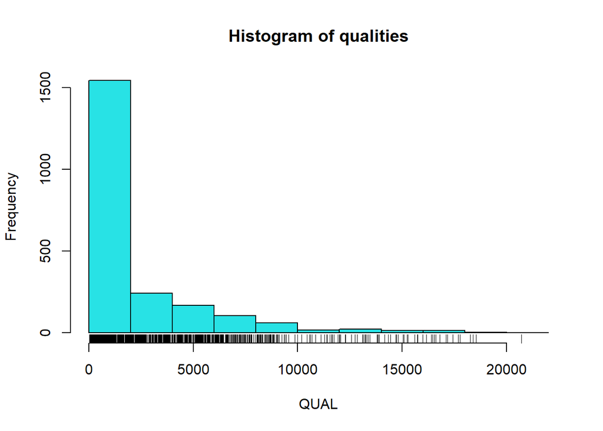

```r
plot(vcf)
```

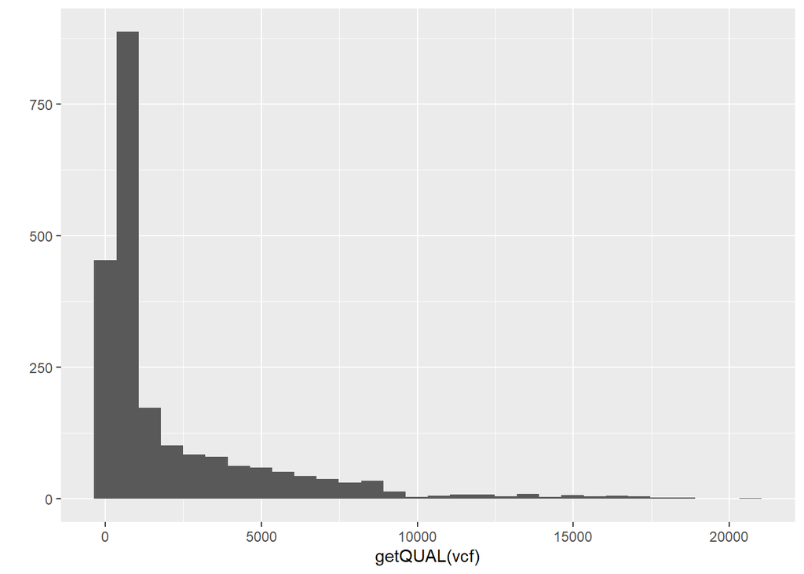

```r
library(ggplot2)
qplot(getQUAL(vcf), geom = "histogram")
```

## 5) How would we query the sample names?

# Use the function:

```r
colnames(vcf@gt)
```

```
##  [1] "FORMAT"        "BL2009P4_us23" "DDR7602"       "IN2009T1_us22"
##  [5] "LBUS5"         "NL07434"       "P10127"        "P10650"
##  [9] "P11633"        "P12204"        "P13527"        "P1362"
## [13] "P13626"        "P17777us22"    "P6096"         "P7722"
## [17] "RS2009P1_us8"  "blue13"        "t30-4"
```

## Part 2: Analysis of genome data

# Read in vcf data:

```r
library('vcfR')
vcf <- read.vcfR("Grunwald/pinfsc50_filtered.vcf.gz")
```

```
## Scanning file to determine attributes.
## File attributes:
##   meta lines: 29
##   header_line: 30
##   variant count: 2190
##   column count: 27
##
Meta line 29 read in.
## All meta lines processed.
## gt matrix initialized.
## Character matrix gt created.
##   Character matrix gt rows: 2190
##   Character matrix gt cols: 27
##   skip: 0
##   nrows: 2190
##   row_num: 0
##
Processed variant 1000
Processed variant 2000
Processed variant: 2190
## All variants processed
```

```r
vcf
```

```
## ***** Object of Class vcfR *****
## 18 samples
## 1 CHROMs
## 2,190 variants
## Object size: 2.9 Mb
## 0 percent missing data
## *****        *****         *****
```

# Converting vcf data to a genlight object

```r
x <- vcfR2genlight(vcf)
x
```

```
##  /// GENLIGHT OBJECT /////////
##
##  // 18 genotypes,  2,146 binary SNPs, size: 240.4 Kb
##  0 (0 %) missing data
##
##  // Basic content
##    @gen: list of 18 SNPbin
##
##  // Optional content
##    @ind.names:  18 individual labels
##    @loc.names:  2146 locus labels
##    @chromosome: factor storing chromosomes of the SNPs
##    @position: integer storing positions of the SNPs
##    @other: a list containing: elements without names
```

```r
# vcfR
gt <- extract.gt(vcf, element = "GT")
gt[c(2,6,18), 1:3]
```

```
##                        BL2009P4_us23 DDR7602 IN2009T1_us22
## Supercontig_1.50_80063 "1|0"         "1|0"   "0|1"
## Supercontig_1.50_80089 "0|0"         "1|0"   "0|1"
## Supercontig_1.50_94108 "0|1"         "0|1"   "1|1"
```

```r
# genlight
t(as.matrix(x))[c(1,5,17), 1:3]
```

```
##                        BL2009P4_us23 DDR7602 IN2009T1_us22
## Supercontig_1.50_80063             1       1             1
## Supercontig_1.50_80089             0       1             1
## Supercontig_1.50_94108             1       1             2
```

```r
library(adegenet)
pop(x) <- as.factor(c("us", "eu", "us", "af", "eu", "us", "mx", "eu", "eu", "sa", "mx", "sa", "us", "sa", "Pmir", "us", "eu", "eu"))
popNames(x)
```

```
## [1] "af"   "eu"   "mx"   "Pmir" "sa"   "us"
```

```r
ploidy(x) <- 2
```

# Distance matrices

```r
x.dist <- dist(x)
```

```r
x.dist <- poppr::bitwise.dist(x)
```

# Creating chromeR objects

```r
library(vcfR)

# Find the files.
vcf_file <- system.file("extdata", "pinf_sc50.vcf.gz", package = "pinfsc50")
dna_file <- system.file("extdata", "pinf_sc50.fasta", package = "pinfsc50")
gff_file <- system.file("extdata", "pinf_sc50.gff", package = "pinfsc50")

# Input the files.
vcf <- read.vcfR(vcf_file, verbose = FALSE)
dna <- ape::read.dna(dna_file, format = "fasta")
gff <- read.table(gff_file, sep="\t", quote="")

# Create a chromR object.
chrom <- create.chromR(name="Supercontig", vcf=vcf, seq=dna, ann=gff, verbose=TRUE)
```

```
## Names in vcf:
```

```
##   Supercontig_1.50
```

```
## Names of sequences:
```

```
##   Supercontig_1.50 of Phytophthora infestans T30-4
```

```
## Names in annotation:
```

```
##   Supercontig_1.50
```

```
## Initializing var.info slot.
```

```
## var.info slot initialized.
```

```r
chrom
```

```
## *****   Class chromR, method Show   *****
## Name: Supercontig
## Chromosome length: 1,042,442 bp
##   Chromosome labels: Supercontig_1.50 of Phytophthora infestans T30-4
## Annotation (@ann) count: 223
##   Annotation chromosome names: Supercontig_1.50
## Variant (@vcf) count: 22,031
##   Variant (@vcf) chromosome names: Supercontig_1.50
## Object size: 24.1 Mb
## Use head(object) for more details.
## *****      End Show (chromR)        *****
```

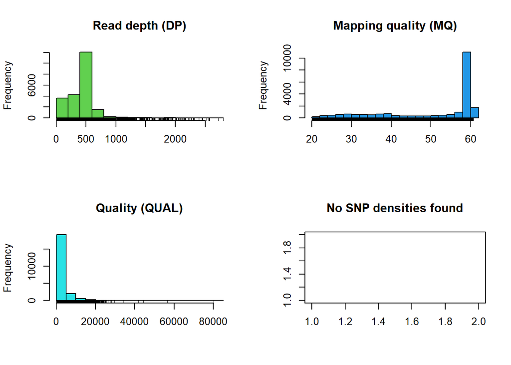

```r
plot(chrom)
```

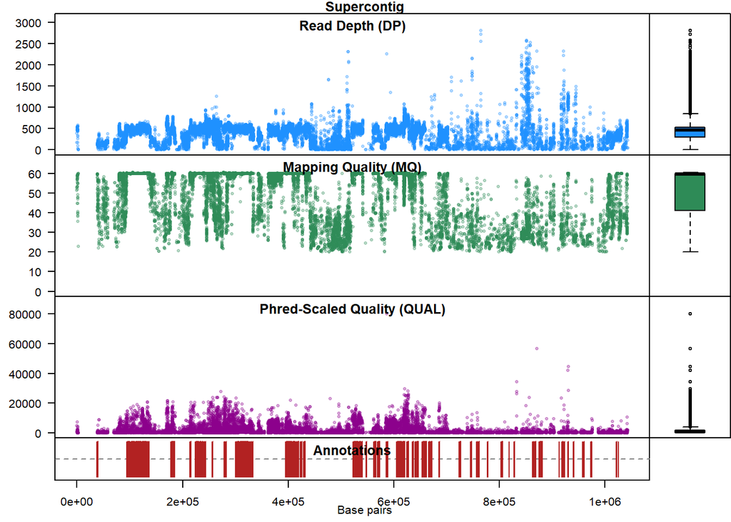

```r
chromoqc(chrom, dp.alpha = 66)
```

# Processing chromeR objects

```r
chrom <- proc.chromR(chrom, verbose = TRUE)
```

```
## Nucleotide regions complete.
```

```
##   elapsed time:  0.72
```

```
## N regions complete.
```

```
##   elapsed time:  0.51
```

```
## Population summary complete.
```

```
##   elapsed time:  1.47
```

```
## window_init complete.
```

```
##   elapsed time:  0
```

```
## windowize_fasta complete.
```

```
##   elapsed time:  0.32
```

```
## windowize_annotations complete.
```

```
##   elapsed time:  0.03
```

```
## windowize_variants complete.
```

```
##   elapsed time:  0
```

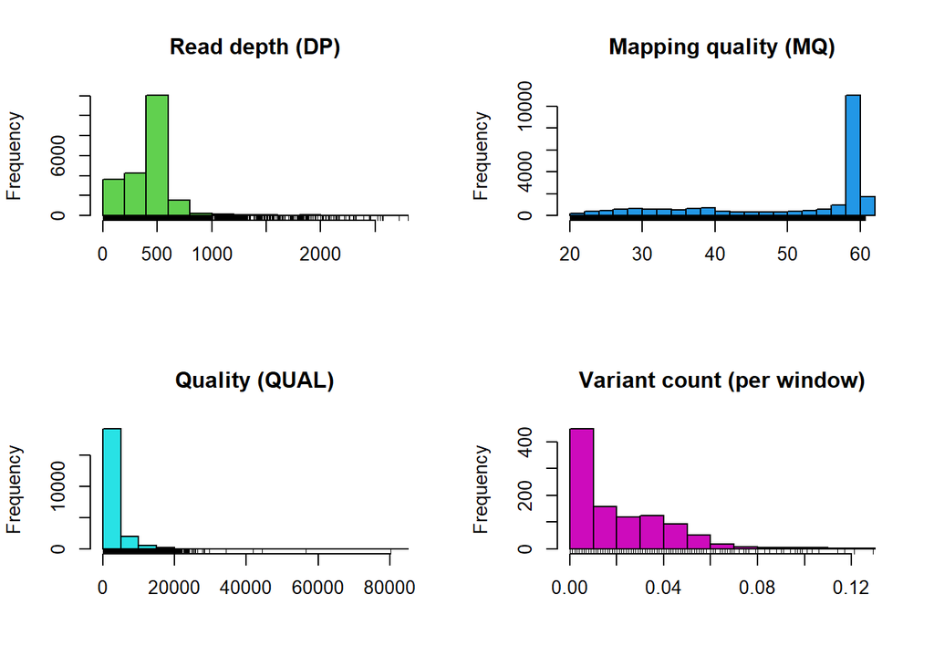

```r
plot(chrom)
```

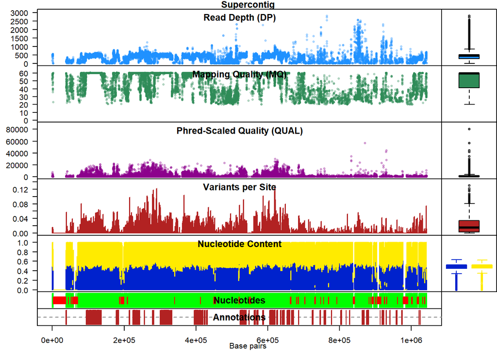

```r
chromoqc(chrom, dp.alpha = 66)
```

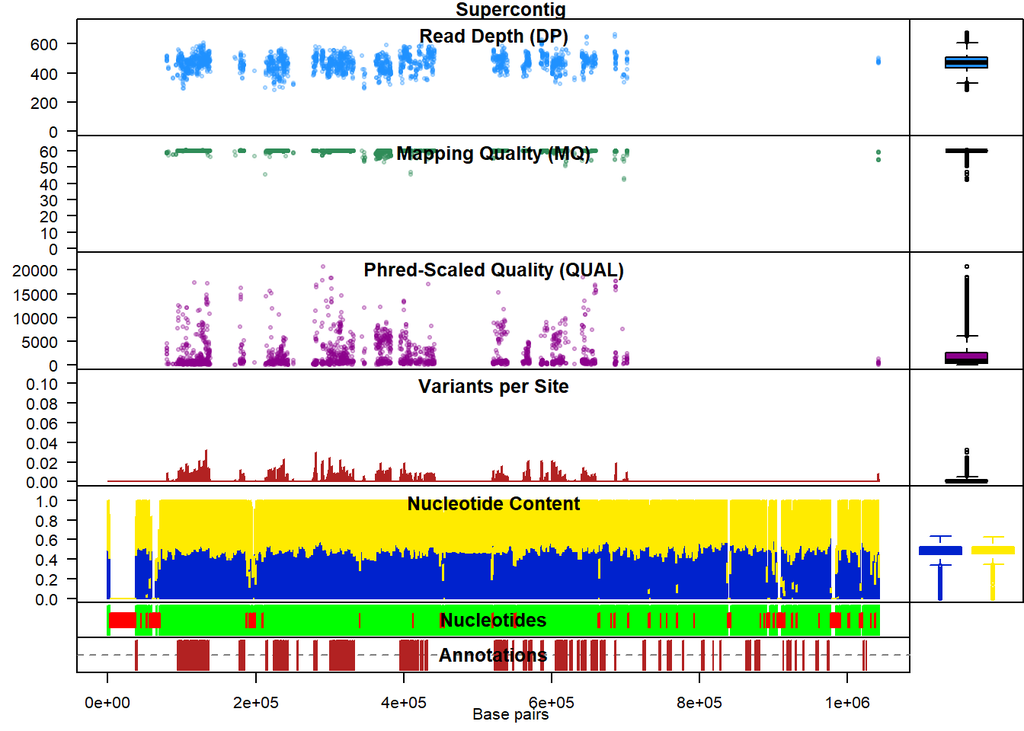

```r
#vcf <- read.vcfR("pinfsc50_qc.vcf.gz", verbose = FALSE)
vcf <- read.vcfR("Grunwald/pinfsc50_filtered.vcf.gz", verbose = FALSE)
chrom <- create.chromR(name="Supercontig", vcf=vcf, seq=dna, ann=gff, verbose=FALSE)
chrom <- proc.chromR(chrom, verbose = FALSE)
chromoqc(chrom, dp.alpha = 66)
```

# Tabular summaries

```r
head(chrom@var.info)
```

```
##              CHROM   POS    MQ  DP mask  n Allele_counts         He       Ne
## 1 Supercontig_1.50 80058 58.96 508 TRUE 18       25,10,1 0.64364712 2.806207
## 2 Supercontig_1.50 80063 58.95 514 TRUE 18         25,11 0.42438272 1.737265
## 3 Supercontig_1.50 80067 58.88 499 TRUE 18         23,13 0.46141975 1.856734
## 4 Supercontig_1.50 80073 58.77 490 TRUE 18          35,1 0.05401235 1.057096
## 5 Supercontig_1.50 80074 58.75 482 TRUE 18         26,10 0.40123457 1.670103
## 6 Supercontig_1.50 80089 58.80 481 TRUE 18         25,11 0.42438272 1.737265
```

```r
head(chrom@win.info)
```

```
##              CHROM window start  end length   A   C   G   T    N other genic
## 1 Supercontig_1.50      1     1 1000   1000 267 213 293 227    0     0     0
## 2 Supercontig_1.50      2  1001 2000   1000 283 206 309 202    0     0     0
## 3 Supercontig_1.50      3  2001 3000   1000 229 213 235 177  146     0     0
## 4 Supercontig_1.50      4  3001 4000   1000   0   0   0   0 1000     0     0
## 5 Supercontig_1.50      5  4001 5000   1000   0   0   0   0 1000     0     0
## 6 Supercontig_1.50      6  5001 6000   1000   0   0   0   0 1000     0     0
##   variants
## 1        0
## 2        0
## 3        0
## 4        0
## 5        0
## 6        0
```

# Genetic differentiation

```r
library(vcfR)
data(vcfR_example)
pop <- as.factor(c("us", "eu", "us", "af", "eu", "us", "mx", "eu", "eu", "sa", "mx", "sa", "us", "sa", "Pmir", "us", "eu", "eu"))
myDiff <- genetic_diff(vcf, pops = pop, method = 'nei')
knitr::kable(head(myDiff[,1:15]))
```

| CHROM | POS | Hs_af | Hs_eu | Hs_mx | Hs_Pmir | Hs_sa | Hs_us | Ht | n_af | n_eu | n_mx | n_Pmir | n_sa | n_us |
| --- | --- | --- | --- | --- | --- | --- | --- | --- | --- | --- | --- | --- | --- | --- |
| Supercontig_1.50 | 2 | 0 | 0.0 | 0.000 | 0.5 | 0.000 | 0.00 | 0.0798611 | 2 | 4 | 4 | 2 | 4 | 8 |
| Supercontig_1.50 | 246 | NaN | 0.0 | 0.375 | NaN | 0.000 | 0.50 | 0.3512397 | 0 | 4 | 4 | 0 | 6 | 8 |
| Supercontig_1.50 | 549 | NaN | 0.0 | NaN | NaN | NaN | 0.50 | 0.4444444 | 0 | 2 | 0 | 0 | 0 | 4 |
| Supercontig_1.50 | 668 | NaN | 0.5 | 0.000 | NaN | 0.000 | 0.50 | 0.5000000 | 0 | 4 | 2 | 0 | 2 | 8 |
| Supercontig_1.50 | 765 | 0 | 0.0 | 0.000 | 0.0 | 0.000 | 0.00 | 0.1107266 | 2 | 12 | 4 | 2 | 4 | 10 |
| Supercontig_1.50 | 780 | 0 | 0.0 | 0.000 | 0.0 | 0.375 | 0.18 | 0.1244444 | 2 | 8 | 4 | 2 | 4 | 10 |

```r
knitr::kable(head(myDiff[,16:19]))
```

| Gst | Htmax | Gstmax | Gprimest |
| --- | --- | --- | --- |
| 0.4782609 | 0.7951389 | 0.9475983 | 0.5047085 |
| NaN | 0.8057851 | NaN | NaN |
| NaN | 0.6666667 | NaN | NaN |
| NaN | 0.8125000 | NaN | NaN |
| 1.0000000 | 0.7543253 | 1.0000000 | 1.0000000 |
| 0.1160714 | 0.8000000 | 0.8625000 | 0.1345756 |

```r
knitr::kable(round(colMeans(myDiff[,c(3:9,16,19)], na.rm = TRUE), digits = 3))
```

|  | x |
| --- | --- |
| Hs_af | 0.176 |
| Hs_eu | 0.188 |
| Hs_mx | 0.168 |
| Hs_Pmir | 0.052 |
| Hs_sa | 0.198 |
| Hs_us | 0.155 |
| Ht | 0.247 |
| Gst | 0.595 |
| Gprimest | 0.632 |

# Another way to summarize data:

```r
library(reshape2)
```

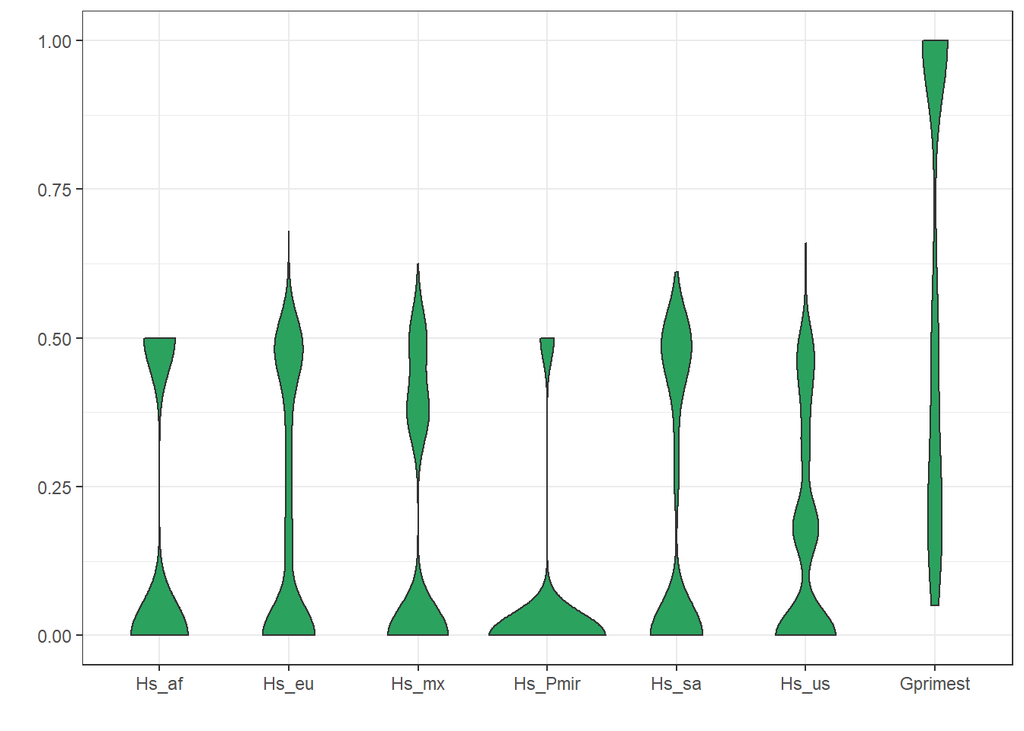

```r
library(ggplot2)

dpf <- melt(myDiff[,c(3:8,19)], varnames=c('Index', 'Sample'), value.name = 'Depth', na.rm=TRUE)
p <- ggplot(dpf, aes(x=variable, y=Depth)) + geom_violin(fill="#2ca25f", adjust = 1.2)
p <- p + xlab("")
p <- p + ylab("")
p <- p + theme_bw()
p
```

# EXERCISES PART 2

# 1) You actually have everything you need to make a Manhattan plot. Can you figure out how to plot G′ST (y-axis) by genomic position (POS)?

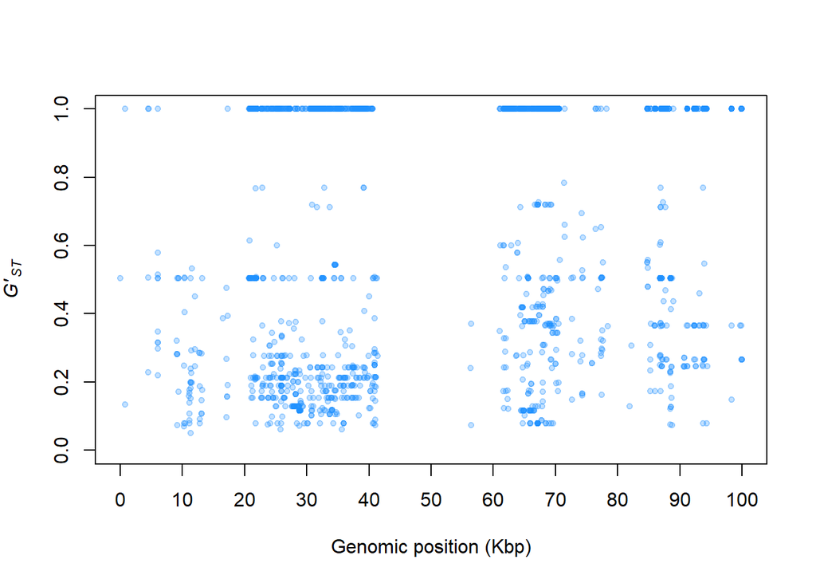

```r
plot(getPOS(vcf), myDiff$Gprimest,  pch = 20, col = "#1E90FF44", xlab = "", ylab = "", ylim = c(0, 1), xaxt = "n")
axis(side = 1, at = seq(0, 1e5, by = 1e4), labels = seq(0, 100, by = 10))
title(xlab='Genomic position (Kbp)')
title(ylab = expression(italic("G'"["ST"])))
```

# 2) This Manhatttan plot shouldlook a bit unusual. Can you think of anything that may be wrong with this analysis?

#The sample size is small and therefore produces the plot seen in question 1.

```r
table(pop)
```

```
## pop
##   af   eu   mx Pmir   sa   us
##    1    6    2    1    3    5
```

# 3) Can you figure out how to zoom in on a particular region of a chromosome in chromoqc()?

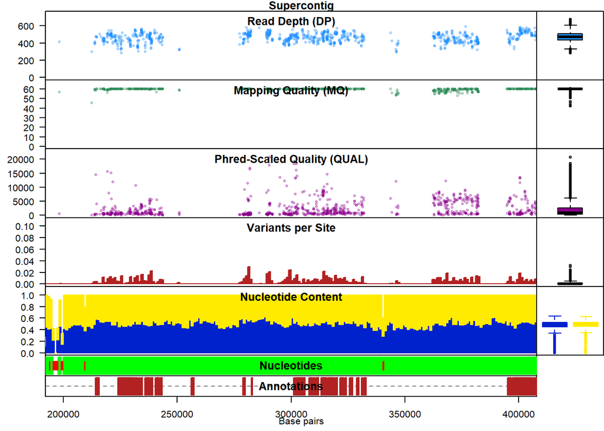

```r
chromoqc(chrom, dp.alpha = 66, xlim = c(2e05, 4e05))
```

# 4) Can you use the function queryMETA() to look for other data in your file that may be of interest?

```r
queryMETA(vcf)
```

```
##  [1] "FILTER=ID=LowQual"
##  [2] "FORMAT=ID=AD"
##  [3] "FORMAT=ID=DP"
##  [4] "FORMAT=ID=GQ"
##  [5] "FORMAT=ID=GT"
##  [6] "FORMAT=ID=PL"
##  [7] "GATKCommandLine=ID=HaplotypeCaller"
##  [8] "INFO=ID=AC"
##  [9] "INFO=ID=AF"
## [10] "INFO=ID=AN"
## [11] "INFO=ID=BaseQRankSum"
## [12] "INFO=ID=ClippingRankSum"
## [13] "INFO=ID=DP"
## [14] "INFO=ID=DS"
## [15] "INFO=ID=FS"
## [16] "INFO=ID=HaplotypeScore"
## [17] "INFO=ID=InbreedingCoeff"
## [18] "INFO=ID=MLEAC"
## [19] "INFO=ID=MLEAF"
## [20] "INFO=ID=MQ"
## [21] "INFO=ID=MQ0"
## [22] "INFO=ID=MQRankSum"
## [23] "INFO=ID=QD"
## [24] "INFO=ID=ReadPosRankSum"
## [25] "INFO=ID=SOR"
## [26] "1 contig=<IDs omitted from queryMETA"
```